# AE Grading Overview

Study: AA-AA-000-0000

gsm.kri Example

Snapshot Date: 2026-09-03

# Set Up

This page provides a sample AE Grading Report generated using the `gsm.kri` package. Expand the “Setup” section below to see the code used to generate the report. Or scroll down for the standard report output.

The report is the visual companion to the two site-level grading metrics, `kri0016` (High-Grade AE Proportion) and `kri0017` (Low-Grade AE Proportion). It is produced by `Report_AEGrading()`, which is wired up as the `report_aegrading` workflow module.

> **Note on the example data.** The `gsm.core` example data has a realistic study-wide grade distribution, but grades are assigned independently of site, so no site deviates from the study and the report has nothing to find. This page therefore redraws `aetoxgr` with `Sim_AEGrading()`, keeping the real subject/site structure and per-site AE burden while giving a few sites deliberate over- and under-grading behaviour. Every number below is illustrative; the mechanics are real.

**Setup**

```r
# Load libraries
library(gsm.core)
library(gsm.mapping)
library(gsm.kri)
library(gsm.reporting)
library(dplyr)
library(tibble)

source("util/Sim_AEGrading.R")

# --- Step 1: Map raw data (real gsm.mapping pipeline) ------------------------
core_mappings <- c(
  "AE", "COUNTRY", "DATAENT", "ENROLL", "SITE", "STUDY", "SUBJ"
)

mappings_wf <- MakeWorkflowList(
  strNames = core_mappings,
  strPath = "workflow/1_mappings",
  strPackage = "gsm.mapping"
)
lRaw <- Ingest(gsm.core::lSource, CombineSpecs(mappings_wf))
```

```
## ℹ Ingesting data for AE.
```

```
## [INFO] Creating a new temporary DuckDB connection.
```

[output not shown]

[output cut: 52 more lines]

[output not shown]

```r
lMapped <- RunWorkflows(mappings_wf, lRaw)
```

[output not shown]

[output cut: 180 more lines]

[output not shown]

```r
# --- Step 2: Simulate site-level grading behaviour (example only) ------------
sim <- Sim_AEGrading(lMapped$Mapped_AE, lMapped$Mapped_SUBJ)
lMapped$Mapped_AE <- sim$AE

# --- Step 3: Run the AE grading metrics --------------------------------------
metric_names <- c("kri0016", "kri0017")
metrics_wf <- MakeWorkflowList(
  strNames = metric_names,
  strPath = "workflow/2_metrics",
  strPackage = "gsm.kri"
)
lAnalyzed <- RunWorkflows(metrics_wf, c(lMapped, list(lWorkflows = metrics_wf)))
```

[output not shown]

[output cut: 13 more lines]

[output not shown]

[output not shown]

[output cut: 50 more lines]

[output not shown]

[output not shown]

```r
# --- Step 4: Build reporting frames (real gsm.reporting pipeline) ------------
reporting_wf <- MakeWorkflowList(
  strNames = c("Results", "Metrics", "Bounds", "Groups"),
  strPath = "workflow/3_reporting",
  strPackage = "gsm.reporting"
)
lReporting <- RunWorkflows(
  reporting_wf,
  c(lMapped, list(lAnalyzed = lAnalyzed, lWorkflows = metrics_wf))
)
```

[output not shown]

[output cut: 11 more lines]

[output not shown]

```r
dfResults <- lReporting$Reporting_Results |>
  FilterByLatestSnapshotDate()

# --- Step 5: Assemble the listings consumed by the report --------------------
lListings <- list(
  Mapped_AE = lMapped$Mapped_AE,
  Mapped_SUBJ = lMapped$Mapped_SUBJ
)
```

**EXPERIMENTAL — FOR EXPLORATORY USE ONLY**  
All findings should be independently confirmed.

# AE Grading Overview

This report examines how consistently investigator sites apply CTCAE severity grading to adverse events. It is a companion to the site-level grading KRIs `kri0016` (High-Grade AE Proportion) and `kri0017` (Low-Grade AE Proportion), and asks a single question: does a site’s distribution of Grade 1–5 events look like the rest of the study? Sites that grade nearly everything as Grade 1, or nearly everything as Grade 3/4, stand out against their peers.

## Study-wide grade distribution

| Grade | Events | % of all AEs |
| --- | --- | --- |
| Grade 1 | 3164 | 48.1% |
| Grade 2 | 1808 | 27.5% |
| Grade 3 | 916 | 13.9% |
| Grade 4 | 471 | 7.2% |
| Grade 5 | 213 | 3.2% |

# Grade distribution by site

Each bar is one site’s severity mix, sorted by the proportion of Grade 3+ events. Sites at the top report the highest share of severe events; sites at the bottom report the lowest. The dashed line marks the study-wide Grade 3+ proportion — bars that break well away from it in either direction are the sites whose grading behaviour differs from their peers.

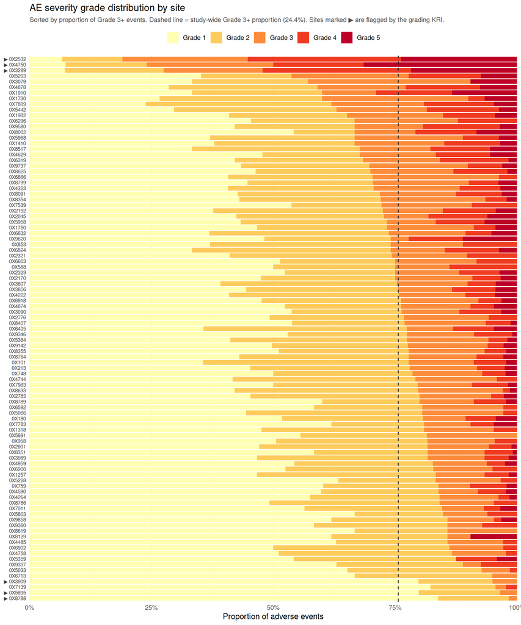

## Flagged sites

| Site | Numerator | Total AEs | Site % | Study % | Z-score | Direction |
| --- | --- | --- | --- | --- | --- | --- |
| 0X2532 | 85 | 105 | 81.0% | 24.4% | 6.26 | Over-grading |
| 0X3289 | 50 | 69 | 72.5% | 24.4% | 4.32 | Over-grading |
| 0X4750 | 41 | 54 | 75.9% | 24.4% | 4.09 | Over-grading |
| 0X8788 | 2 | 117 | 1.7% | 24.4% | -2.65 | Under-grading |
| 0X5895 | 4 | 114 | 3.5% | 24.4% | -2.40 | Under-grading |
| 0X3909 | 5 | 99 | 5.1% | 24.4% | -2.07 | Under-grading |

Sites flagged by the grading metric on a two-sided adjusted z-score. Over-grading means the site reports a higher proportion of the graded events of interest than the study; under-grading, a lower proportion.

# Method notes and limitations

- **Grades are treated as reported.** No re-derivation from lab values or outcome data is attempted; the report measures internal consistency across sites, not clinical correctness.
- **The study is its own comparator.** If grading drifts study-wide, this report will not detect it — every site is compared to the study average.
- **The overall severity mix is a blunt instrument.** A site can report a perfectly average proportion of severe events while still grading individual event types inconsistently. Detecting that requires comparing sites against the study term by term, which is not part of this report.
- **Small sites are excluded.** Sites below 20 graded AEs are dropped from the chart, so a small site with a genuine grading problem may not appear at all.